# **HarvardX: PH125.9x: Data Science: Capstone: Predicting the Chance of a Patient Falling Using Data from China**

## **Exploratory Data Analysis- Training set**

### Data Structure

I first examine the structure of the data. Note that except for the dependent variable that is a factor with six levels, all the other variables are numeric. The training dataset has 11465 observations of 7 variables. The dependent variable is `activity`, a factor variable with 6 levels as follows.

0. Standing
1. Walking
2. Sitting
3. Falling
4. Cramps
5. Running

The level of interest in this case is to forecast whether or not a patient will fall. When weighing the options, it is better to predict that a patient will not fall when in fact they do not fall. While its also good to predict which patient will fall, the former has more weight. For this reason, I evaluate the model mainly using `specificity` and `balanced accuracy` rather than `sensitivity`.

The dependent variables are as follows.

1. time: monitoring time
2. sl: sugar level.
3. eeg: eeg monitoring rate- electroencephalogram (EEG) is a test that detects electrical activity in the brain.
4. bp: blood pressure.
5. hr: heart beat rate.
6. circulation: blood circulation.

I summarise the data below.

```r
## Overview of the training data.
## Structure of the training data
str(fall_train)
```

```
## 'data.frame':    11465 obs. of  7 variables:
##  $ activity   : Factor w/ 6 levels "3","0","1","2",..: 2 2 2 2 2 2 2 2 2 2 ...
##  $ time       : num  10256 6628 7837 10788 18609 ...
##  $ sl         : num  66668 6491 5545 103850 300553 ...
##  $ eeg        : num  -6050 -1923 -2661 -4705 -12391 ...
##  $ bp         : int  97 23 41 85 73 264 61 18 63 92 ...
##  $ hr         : int  207 100 126 237 464 465 390 111 299 365 ...
##  $ circluation: int  3048 485 371 4804 10829 8741 6741 345 7334 3633 ...
```

```r
## First 6 observations of the training dataset
head(fall_train) %>% knitr::kable(caption = "First Six Observations of the Training Set")
```

First Six Observations of the Training Set

|  | activity | time | sl | eeg | bp | hr | circluation |
| --- | --- | --- | --- | --- | --- | --- | --- |
| 13 | 0 | 10255.70 | 66668.00 | -6050.00 | 97 | 207 | 3048 |
| 18 | 0 | 6628.08 | 6490.83 | -1923.04 | 23 | 100 | 485 |
| 19 | 0 | 7836.78 | 5545.00 | -2661.00 | 41 | 126 | 371 |
| 20 | 0 | 10787.80 | 103850.00 | -4705.00 | 85 | 237 | 4804 |
| 27 | 0 | 18609.30 | 300553.00 | -12391.00 | 73 | 464 | 10829 |
| 29 | 0 | 23099.10 | 280276.00 | -13215.00 | 264 | 465 | 8741 |

```r
## last 6 observations of the training dataset
tail(fall_train) %>% knitr::kable(caption = "Last Six Observations of the Training Set")
```

Last Six Observations of the Training Set

|  | activity | time | sl | eeg | bp | hr | circluation |
| --- | --- | --- | --- | --- | --- | --- | --- |
| 16325 | 5 | 9363.74 | 37928.80 | -3795.490 | 38 | 180 | 2054 |
| 16334 | 5 | 13684.60 | 52970.90 | -5976.250 | 53 | 288 | 2334 |
| 16346 | 5 | 10137.40 | 34148.60 | -3518.520 | 95 | 176 | 1922 |
| 16357 | 5 | 4795.02 | 3404.89 | -1322.750 | 41 | 71 | 249 |
| 16366 | 5 | 13250.40 | 51768.90 | -6069.660 | 52 | 288 | 2334 |
| 16370 | 5 | 3825.38 | 1220.87 | -768.261 | 37 | 51 | 102 |

```r
## Number of rows in the training dataset
nrow(fall_train)
```

```
## [1] 11465
```

```r
## Number of columns in the training dataset
ncol(fall_train)
```

```
## [1] 7
```

### Missing Data

As the summary below shows, the training data has no missing data points. Hence, I explore the data using visualizations next using the `missmap` function from the Amelia package.

```r
# **************************************
# Exploratory data analysis: missing data
## Check for missing data.
sapply(fall_train, is.na) %>%

  ## Get the colsums of the logical dataframe.
  ## The colsums represent missing data for each column.
  colSums() %>%

  ## Make a tibble of column names and missing values.
  dplyr::tibble(variables = names(fall), missing = .) %>%

  ## Arrange missing values in descending order of missingness
  dplyr::arrange(desc(missing)) %>%

  ## Get the top 7 (number of columns)
  ## Our tibble has no missing data.
  head(7) %>%

  ## make a nice table
  knitr::kable(caption = "Missing Data in the Training Set")
```

Missing Data in the Training Set

| variables | missing |
| --- | --- |
| activity | 0 |
| time | 0 |
| sl | 0 |
| eeg | 0 |
| bp | 0 |
| hr | 0 |
| circluation | 0 |

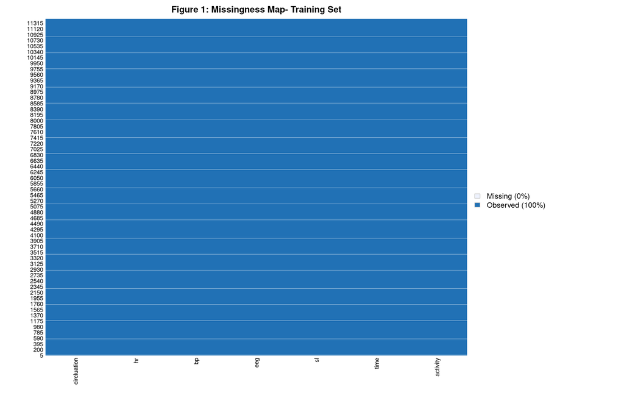

```r
## Visualizing missingness of data
Amelia::missmap(fall_train, main = "Figure 1: Missingness Map- Training Set")
```

```r
## Again there is no missing data
```

### Other Summary Statistics

The independent variable is categorical with six categories. The category of interest is 3 (falling). While the other categories are important, maximizing the prediction for falling remains the most important objective as the other activities are not as harmful.

```r
## Summary statistics for the dependent variables
summary(fall_train$activity) %>% knitr::kable(caption = "Summary of Dependent Variable")
```

Summary of Dependent Variable

|  | x |
| --- | --- |
| 3 | 2511 |
| 0 | 3228 |
| 1 | 355 |
| 2 | 1751 |
| 4 | 2447 |
| 5 | 1173 |

```r
##***************************************************
# Exploratory data analysis: summary statistics
fall_train %>%

  ## Deselect the activity column
  select(-activity) %>%

  ## Make a table of summary statistics
  skimr::skim() %>%

  ## Remove some uninformative columns
  dplyr::select(-contains(c("missing", "complete", "hist", "skim_type"))) %>%

  ## Rename remaining columns
  dplyr::rename(Variable = skim_variable,

                Mean = numeric.mean, SD = numeric.sd,

                Min = numeric.p0, Q1 = numeric.p25,

                Median = numeric.p50,

                Q3 = numeric.p75, Max = numeric.p100) %>%

  ## make a nice table
  knitr::kable(caption = "Summary Statistics for the `Fall` dataset", align = "l")
```

Summary Statistics for the `Fall` dataset

| Variable | Mean | SD | Min | Q1 | Median | Q3 | Max |
| --- | --- | --- | --- | --- | --- | --- | --- |
| time | 10963.86416 | 5279.52148 | 1.95423e+03 | 7269.79 | 9779.28 | 13503.90 | 50895.5 |
| sl | 75951.65790 | 129410.22133 | 4.22242e+01 | 10069.00 | 32234.50 | 80896.80 | 2426140.0 |
| eeg | -4562.64414 | 31952.36356 | -3.39680e+06 | -5646.00 | -3372.05 | -2170.96 | 144000.0 |
| bp | 58.43044 | 48.30781 | 0.00000e+00 | 26.00 | 44.00 | 78.00 | 506.0 |
| hr | 212.29551 | 130.28488 | 3.30000e+01 | 119.00 | 180.00 | 271.00 | 986.0 |
| circluation | 2913.92708 | 3850.79797 | 5.00000e+00 | 587.00 | 1626.00 | 3539.00 | 52210.0 |

### Data Visualization

In this section, I visualize the training dataset. First, I visualize the correlation matrix that shows extremely high correlation between the independent variables, for instance between `circulation` and `heart rate`. In its current form, running models using collinear data is likely yo yield unstable coefficients and hence unstable predictions. For this reason, I will run principal components analysis on the independent variables.

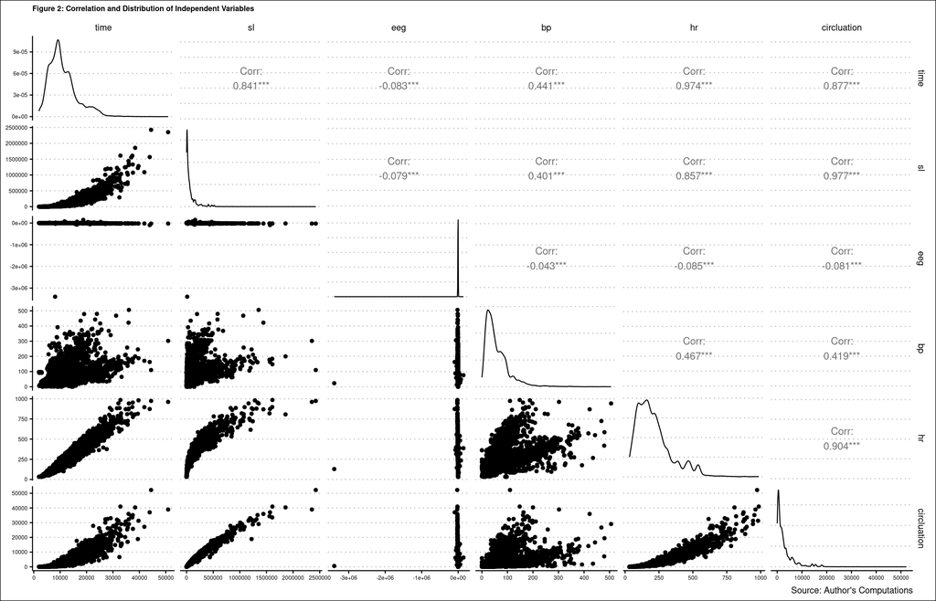

```r
# Exploratory data analysis: data visualization
fall_train[,-1] %>% GGally::ggpairs() +

  ## Add title and caption
  labs(title = "Figure 2: Correlation and Distribution of Independent Variables",

       caption = "Source: Author's Computations") +

       ## Add themes and adjust the font size plot title
       ggthemes::theme_clean() + theme(plot.title = element_text(size = 8)) +

       ## Adjust font sizes of axis text
       theme(axis.text = element_text(size = 6))
```

### Correlation among the variables

Figure 2 shows the high degree of correlation between the independent variables which could make a model have unstable coefficients. I intend to correct the multicollinearity by running principal components analysis.

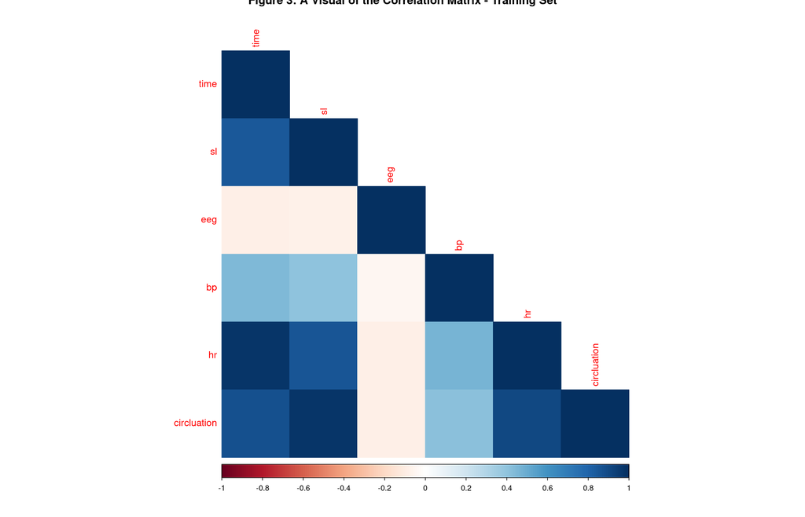

```r
## Visualize the correlation
## Run correlation on independent variables and call the corrplot
cor(fall_train[,-1]) %>% corrplot::corrplot(method = "color",

            ## Specify the corrplot type and add title
            type = "lower", title = "Figure 3: A Visual of the Correlation Matrix - Training Set")
```

### Class Balance/ Imbalance

Here I check for data balance and find that class 1 has very low prevalence that is likely to affect predictive accuracy on the test set. I intend to correct for the low prevalence by up-sampling the classes that have very low prevalence in order to create a balanced dataset.

```r
## Check for possible class imbalance on the dependent variable
## Make a table of class counts
table(fall_train$activity)
```

```
##
##    3    0    1    2    4    5
## 2511 3228  355 1751 2447 1173
```

```r
## Make a proportionate table of class counts
prop.table(table(fall_train$activity))
```

```
##
##         3         0         1         2         4         5
## 0.2190144 0.2815526 0.0309638 0.1527257 0.2134322 0.1023114
```

```r
# Class 1 has a problem of low prevalence.
```

## **Method**

I adopt the following strategy;

### Principal Components Analysis and Handling Class Imbalance

In this section, I do principal components analysis (PCA) and balance the datasets. Note that I have applied the transformation to deal with extreme values that exist in our [data](https://bookdown.org/max/FES/numeric-many-to-many.html#spatial-sign).

```r
## Create a PCA recipe
pca_recipe <- recipe(activity ~ ., data = fall_train)

## Do the PCA analysis
pca_trans <- pca_recipe %>%

  ## Ensure all predictors have a mean of zero
  step_center(all_predictors()) %>%

  ## Ensure all predictors have a standard deviation of one
  step_scale(all_predictors()) %>%

  ## Run the principal components analysis
  step_pca(all_predictors()) %>%

  ## Apply adjustment to deal with outliers
  step_spatialsign(all_predictors()) %>%

  ## Adjust data to deal with missing values
  step_upsample(activity, over_ratio = 1) %>%

  ## Appply alll the steps above and generate new dataset.
  prep()
```

### Visualizing the Principal Components

Here, I extract the standard deviations, compute the variance and the cumulative variance for the PCs. The data shows that the first principal component accounts for about 66% of the variability while the second PC accounts for 17% of the variation.

```r
## Check the names of the dependent variables
names(pca_trans)
```

```
##  [1] "var_info"       "term_info"      "steps"          "template"
##  [5] "levels"         "retained"       "requirements"   "tr_info"
##  [9] "orig_lvls"      "last_term_info"
```

```r
## Access the standard deviations
sdev <- pca_trans$steps[[3]]$res$sdev

# View the standard deviations output
sdev
```

```
## [1] 1.9941791 0.9952037 0.8673943 0.4869939 0.1728212 0.1158289
```

```r
## The contribution of PCA to the total variation
variance_explained <- (sdev ^ 2) / sum(sdev ^ 2)

# The variance explained by each principal component
variance_explained
```

```
## [1] 0.662791684 0.165071746 0.125395480 0.039527175 0.004977860 0.002236054
```

Here, I make the scree plot showing the contribution of each principal component to the overall variability in the data.

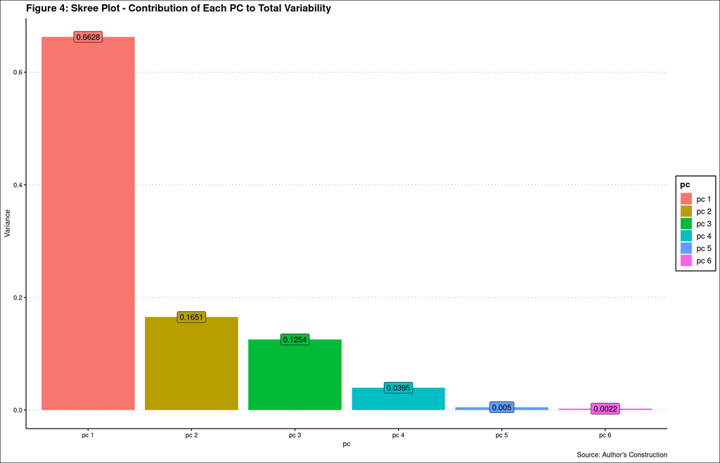

```r
## Plot a scree plot
## Create dataframe of principal components and variance explained by each PC>
data.frame(pc = paste("pc", 1:length(variance_explained)), variance = variance_explained) %>%

  # Call ggplot and supply the axes
  ggplot(aes(x = pc, y = variance, fill = pc)) +

  ## Add the geoms- geom_col and geom_label
  geom_col() + geom_label(show.legend = FALSE, mapping = aes(label = round(variance, 4))) +

  # Add a title
  ggtitle("Figure 4: Skree Plot - Contribution of Each PC to Total Variability") +

  # Remove title
  theme(legend.position = "none") +

  # Add a pleasant theme
  ggthemes::theme_clean() +

  # Add labels and caption
  labs(y = "Variance", caption = "Source: Author's Construction")
```

In this section I make the plot for the cumulative variance. both the summary and the graph show that the first four principal components account for over 99% of the variability.

```r
## Plot a scree plot
## The cumulative variance captured by the PCAs
variance_explained_cum <- cumsum(sdev ^ 2) / sum(sdev ^ 2)

## View the cumulative variance explained
variance_explained_cum
```

```
## [1] 0.6627917 0.8278634 0.9532589 0.9927861 0.9977639 1.0000000
```

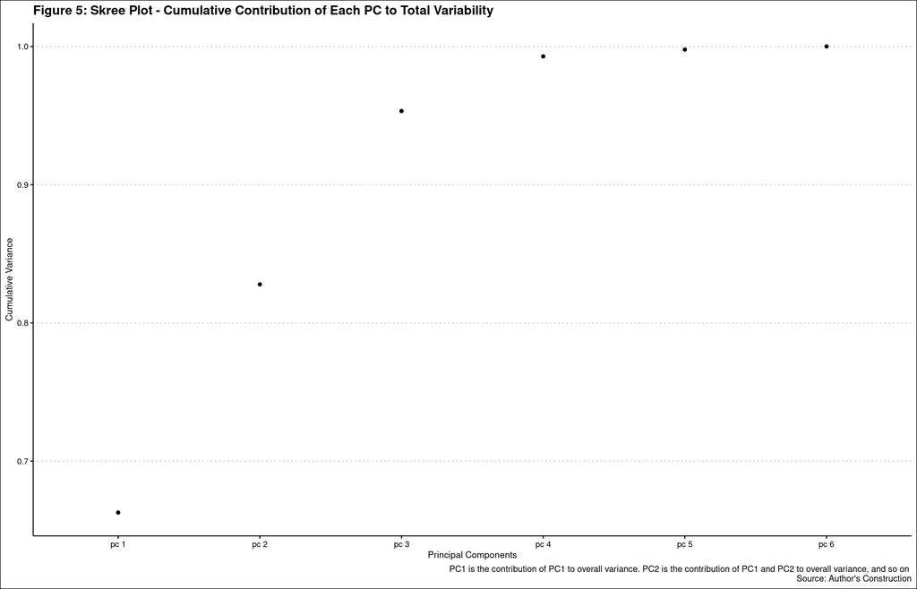

```r
## Create a dataframe of principal components and cumulative variance
data.frame(pc = paste("pc", 1:length(variance_explained_cum)),

           variance = variance_explained_cum) %>%

  ## Specify the axes
  ggplot(aes(x = pc, y = variance, group = pc)) +

  # Add a geom
  geom_point() +

  # Add a title
  ggtitle("Figure 5: Skree Plot - Cumulative Contribution of Each PC to Total Variability") +

  # remove legend
  theme(legend.position = "none") +

  # Add a nice theme
  ggthemes::theme_clean() +

  # Add axes labels and title
  labs(y = "Cumulative Variance", x = "Principal Components", caption = "PC1 is the contribution of PC1 to overall variance. PC2 is the contribution of PC1 and PC2 to overall variance, and so on \n Source: Author's Construction")
```

```r
## Extract the transformed dataset
fall_train <- pca_trans %>% juice()

## The number of rows in the training dataset containing pcas
pca_trans %>% juice() %>% nrow()
```

```
## [1] 19368
```

```r
## Checking class balances by dependent variable
table(pca_trans %>%

        ## Extract transformed data
        juice() %>%

        ## Select dependent variable to check for balance in classes
        select(activity)) %>%

        ## Make a nice table and add title
        knitr::kable(caption = "Distribution of Classes")
```

Distribution of Classes

| activity | Freq |
| --- | --- |
| 3 | 3228 |
| 0 | 3228 |
| 1 | 3228 |
| 2 | 3228 |
| 4 | 3228 |
| 5 | 3228 |

```r
## Summary of the PCAs
pca_trans %>%

  ## Extract transformed data
  juice() %>%

  # Select all variables except activity
  select(-activity) %>%

  ## Summarize the data
  skim_without_charts() %>%

  ## Select some variables in the resulting table
  select(-skim_type, -n_missing, -complete_rate) %>%

  ## Make a nice table
  knitr::kable(caption = "Summary Statistics for PCAs in the training set")
```

Summary Statistics for PCAs in the training set

| skim_variable | numeric.mean | numeric.sd | numeric.p0 | numeric.p25 | numeric.p50 | numeric.p75 | numeric.p100 |
| --- | --- | --- | --- | --- | --- | --- | --- |
| PC1 | -0.3311002 | 0.7324191 | -0.9993410 | -0.9443104 | -0.7607755 | 0.3784137 | 0.9987812 |
| PC2 | -0.0029457 | 0.0443862 | -0.9170863 | -0.0193300 | -0.0003134 | 0.0142165 | 0.9989081 |
| PC3 | -0.0461149 | 0.4929493 | -0.9983935 | -0.3216948 | -0.1837881 | 0.1533594 | 0.9992720 |
| PC4 | 0.0519831 | 0.2987749 | -0.5785683 | -0.1862040 | -0.0179253 | 0.2256539 | 0.9970300 |
| PC5 | 0.0016704 | 0.1220847 | -0.8874046 | -0.0428751 | 0.0095705 | 0.0502035 | 0.9220046 |

In this section, I examine the distribution of the values of each principal components to see the extent to which outliers exist.

```r
## Checking for extreme values
pca_trans %>% juice() %>%

  ## Convert the data to tidy format
  pivot_longer(-activity, names_to = "pc", values_to = "value") %>%

  ## Filter for values that meet threshold of 7.5 to filter out extreme values
  filter(value > 7.5)
```

```
## # A tibble: 0 × 3
## # … with 3 variables: activity <fct>, pc <chr>, value <dbl>
```

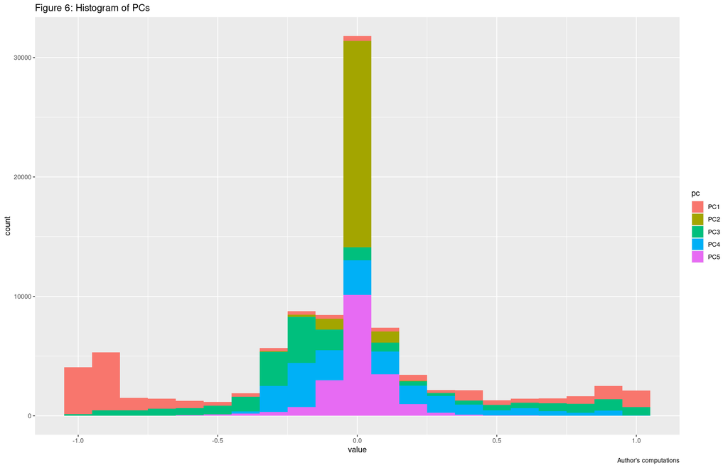

```r
## Plot histogram for PCAs
pca_trans %>% juice() %>%

  ## Convert data to tidy format
  pivot_longer(-activity, names_to = "pc", values_to = "value") %>%

  ## Filter for values within limits to avoid extreme values
  filter(value <= 7.5 & value >= -7.5) %>%

  ## Plot the data by supplying axes
  ggplot(mapping = aes(x = value, fill = pc),

         color = "black") +

  ## Add the geom and specify binwidth
  geom_histogram(binwidth = 0.1) +

  ## Add titles and labels
  labs(title = "Figure 6: Histogram of PCs", caption = "Author's computations")
```

Next, I visualize the first 2 PCs

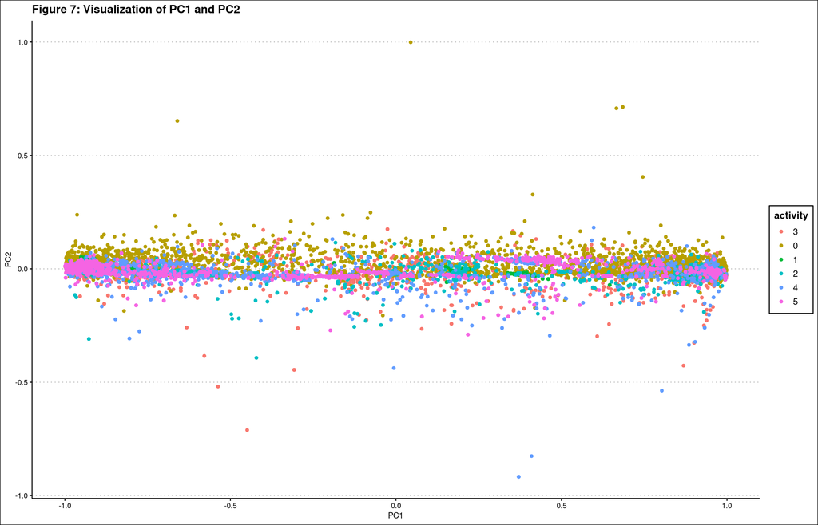

```r
pca_trans %>%

  ## Extract transformed variables - the principal components
  juice() %>%

  ## Plot the first two principal components
  ggplot(mapping = aes(x = PC1, y = PC2, color = activity)) +

   ## Add a geom and a pleasant theme
   geom_point() + ggthemes::theme_clean() +

  ## Add labels and titles
  labs(title = "Figure 7: Visualization of PC1 and PC2")
```

Next, I apply the same transformation I have made on the training set to the testing set. Here, I use a function `bake`.

```r
## Transform the testing data similar to the training data
fall_test <- pca_trans %>%

  ## Use of bake function to generate testing test transformed exactly like the training set
  bake(fall_test)
```

## **Running the ML models**

I now run machine learning models and evaluate each of them in the following order.

1. Classification tree.
2. Random Forest.
3. K-Nearest Neighbours.
4. Extreme Gradient Boosting.
5. Generalized Multinomial Logit Model.
6. Ensemble of all the models above.

In all cases, I run a 10-fold cross validation and set a random seed as follows.

```r
## Set seed to be used in the models
seeds <- set.seed(123, sample.kind = "Rounding")

## Set up cross validation parameters
control <- trainControl(method = "repeatedcv",

                     repeats = 10,

                     seeds = seeds)
```

### Classification tree

```r
# The classification tree model
tree <- caret::train(activity ~ .,

                     data = fall_train,

                     # specify engine to use
                     method = "rpart",

                     # Set up cross validation
                     trControl = control,

                     # Set up metric to use
                     metric = "Accuracy",

                     # Tuning parameters
                     tuneGrid = expand.grid(cp = seq(0, 0.05, 0.01)))

# make predictions on the test set
tree_prediction <- predict(tree, newdata = fall_test)

# Generate confusion matrix on the test set
confusionMatrix(tree_prediction, fall_test$activity)
```

```
## Confusion Matrix and Statistics
##
##           Reference
## Prediction   3   0   1   2   4   5
##          3 471 140   1 113 189  53
##          0 114 880   3  53  86  49
##          1  21  22 107  71  24  12
##          2 169  83  26 417  68  32
##          4 199 134   5  53 467 111
##          5 103 121   5  44 213 258
##
## Overall Statistics
##
##                Accuracy : 0.5288
##                  95% CI : (0.5147, 0.5428)
##     No Information Rate : 0.2807
##     P-Value [Acc > NIR] : < 2.2e-16
##
##                   Kappa : 0.4148
##
##  Mcnemar's Test P-Value : < 2.2e-16
##
## Statistics by Class:
##
##                      Class: 3 Class: 0 Class: 1 Class: 2 Class: 4 Class: 5
## Sensitivity           0.43733   0.6377  0.72789  0.55526  0.44604  0.50097
## Specificity           0.87083   0.9138  0.96855  0.90927  0.87028  0.88960
## Pos Pred Value        0.48707   0.7426  0.41634  0.52453  0.48194  0.34677
## Neg Pred Value        0.84658   0.8660  0.99142  0.91897  0.85309  0.93841
## Prevalence            0.21904   0.2807  0.02990  0.15274  0.21293  0.10474
## Detection Rate        0.09579   0.1790  0.02176  0.08481  0.09498  0.05247
## Detection Prevalence  0.19666   0.2410  0.05227  0.16168  0.19707  0.15131
## Balanced Accuracy     0.65408   0.7757  0.84822  0.73226  0.65816  0.69528
```

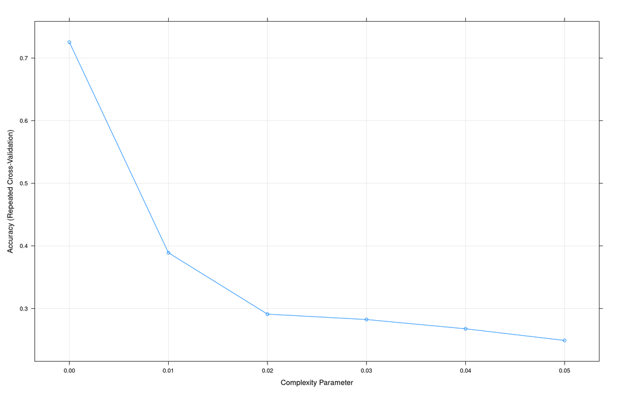

```r
plot(tree)
```

```r
#rpart.plot(tree$finalModel)
```

### The Random Forest Model

```r
## The random forest model
## Set up the tuning parameters
tunegrid <- expand.grid(.mtry= sqrt(ncol(fall_train)))

## Set up the random forest model
rf_default <- caret::train(activity ~ ., data = fall_train,

              # Set up engine, cross validation and tuning parameters
              method = "rf", tunegrid = tunegrid, trControl = control)

## make predictions on the test set
rf_prediction <- predict(rf_default, newdata = fall_test)

## generate confusion matrix
confusionMatrix(rf_prediction, fall_test$activity)
```

```
## Confusion Matrix and Statistics
##
##           Reference
## Prediction    3    0    1    2    4    5
##          3  593   70    1   99  174   36
##          0   94 1119    4   59   75   52
##          1    9    5  105   41   14    5
##          2  162   43   31  491   49   23
##          4  171   87    3   44  597  123
##          5   48   56    3   17  138  276
##
## Overall Statistics
##
##                Accuracy : 0.6469
##                  95% CI : (0.6334, 0.6603)
##     No Information Rate : 0.2807
##     P-Value [Acc > NIR] : < 2.2e-16
##
##                   Kappa : 0.5558
##
##  Mcnemar's Test P-Value : 0.0002631
##
## Statistics by Class:
##
##                      Class: 3 Class: 0 Class: 1 Class: 2 Class: 4 Class: 5
## Sensitivity            0.5506   0.8109  0.71429  0.65379   0.5702  0.53592
## Specificity            0.9010   0.9197  0.98449  0.92607   0.8894  0.94048
## Pos Pred Value         0.6095   0.7976  0.58659  0.61452   0.5824  0.51301
## Neg Pred Value         0.8773   0.9257  0.99114  0.93686   0.8844  0.94542
## Prevalence             0.2190   0.2807  0.02990  0.15274   0.2129  0.10474
## Detection Rate         0.1206   0.2276  0.02135  0.09986   0.1214  0.05613
## Detection Prevalence   0.1979   0.2853  0.03640  0.16250   0.2085  0.10942
## Balanced Accuracy      0.7258   0.8653  0.84939  0.78993   0.7298  0.73820
```

### K-Nearest Neighbours (KNN)

```r
## K-Nearest Neighbours (KNN)
## Set up the model and cross validation
knn <- train(activity ~ ., data = fall_train, method = "knn",

             trControl = control)


# Generate the confusion matrix
confusionMatrix(fall_test$activity, predict(knn, newdata = fall_test))
```

```
## Confusion Matrix and Statistics
##
##           Reference
## Prediction   3   0   1   2   4   5
##          3 545  44  20 191 176 101
##          0 150 674  29 113 200 214
##          1   1   0 126  17   2   1
##          2 109  12  88 460  41  41
##          4 179  35  37  85 498 213
##          5  50  25  18  20 106 296
##
## Overall Statistics
##
##                Accuracy : 0.5286
##                  95% CI : (0.5145, 0.5426)
##     No Information Rate : 0.2103
##     P-Value [Acc > NIR] : < 2.2e-16
##
##                   Kappa : 0.4227
##
##  Mcnemar's Test P-Value : < 2.2e-16
##
## Statistics by Class:
##
##                      Class: 3 Class: 0 Class: 1 Class: 2 Class: 4 Class: 5
## Sensitivity            0.5271   0.8532  0.39623  0.51919   0.4868   0.3418
## Specificity            0.8630   0.8289  0.99543  0.92781   0.8590   0.9459
## Pos Pred Value         0.5060   0.4884  0.85714  0.61252   0.4756   0.5748
## Neg Pred Value         0.8727   0.9672  0.95975  0.89774   0.8643   0.8705
## Prevalence             0.2103   0.1607  0.06467  0.18019   0.2081   0.1761
## Detection Rate         0.1108   0.1371  0.02563  0.09355   0.1013   0.0602
## Detection Prevalence   0.2190   0.2807  0.02990  0.15274   0.2129   0.1047
## Balanced Accuracy      0.6950   0.8410  0.69583  0.72350   0.6729   0.6439
```

### Extreme Gradient Boosting (XGBoost)

In this section, I run the extreme gradient boosting (XGBoost) model. XGBoost refers to the engineering goal to push the limit of computations resources for boosted tree algorithms.

```r
# The XGboost model
## Set up the tuning parameters
tune_grid <- expand.grid(nrounds = 200,
                        max_depth = 5,
                        eta = 0.05,
                        gamma = 0.01,
                        colsample_bytree = 0.75,
                        min_child_weight = 0,
                        subsample = 0.5)

## Set up model, cross validation and tuning parameters
xgb_model <- train(activity ~., data = fall_train, method = "xgbTree",
                trControl = control,
                tuneGrid = tune_grid,
                tuneLength = 10)

## generate confusion matrix for the test set predictions
confusionMatrix(fall_test$activity, predict(xgb_model, newdata = fall_test))
```

```
## Confusion Matrix and Statistics
##
##           Reference
## Prediction   3   0   1   2   4   5
##          3 566  91  18 160 172  70
##          0 125 972  17  74  95  97
##          1   0   3 122  19   2   1
##          2 117  54  79 414  57  30
##          4 209  71  42  91 464 170
##          5  51  38  22  20 113 271
##
## Overall Statistics
##
##                Accuracy : 0.5713
##                  95% CI : (0.5573, 0.5852)
##     No Information Rate : 0.2499
##     P-Value [Acc > NIR] : < 2.2e-16
##
##                   Kappa : 0.4665
##
##  Mcnemar's Test P-Value : < 2.2e-16
##
## Statistics by Class:
##
##                      Class: 3 Class: 0 Class: 1 Class: 2 Class: 4 Class: 5
## Sensitivity            0.5300   0.7909  0.40667   0.5321  0.51384  0.42410
## Specificity            0.8672   0.8894  0.99459   0.9186  0.85476  0.94296
## Pos Pred Value         0.5255   0.7043  0.82993   0.5513  0.44317  0.52621
## Neg Pred Value         0.8693   0.9273  0.96268   0.9126  0.88656  0.91640
## Prevalence             0.2172   0.2499  0.06101   0.1582  0.18365  0.12996
## Detection Rate         0.1151   0.1977  0.02481   0.0842  0.09437  0.05511
## Detection Prevalence   0.2190   0.2807  0.02990   0.1527  0.21293  0.10474
## Balanced Accuracy      0.6986   0.8401  0.70063   0.7254  0.68430  0.68353
```

### Multinomial Logit Model

```r
## Set up the multinomial logit model
multinom <- multinom(activity ~ ., data = fall_train)
## Predict the multinomial logit model on the test set
multinom_predict <- predict(multinom, newdata = fall_test)

## Get confusion matrix
confusionMatrix(multinom_predict, fall_test$activity)
```

```
## Confusion Matrix and Statistics
##
##           Reference
## Prediction   3   0   1   2   4   5
##          3 319 102   5  92 202  49
##          0 152 771  17  71 113  52
##          1 317 280  92 382 292 145
##          2  88  50   7  65  77  44
##          4 103  54   1  60 148  83
##          5  98 123  25  81 215 142
##
## Overall Statistics
##
##                Accuracy : 0.3126
##                  95% CI : (0.2996, 0.3258)
##     No Information Rate : 0.2807
##     P-Value [Acc > NIR] : 4.425e-07
##
##                   Kappa : 0.1866
##
##  Mcnemar's Test P-Value : < 2.2e-16
##
## Statistics by Class:
##
##                      Class: 3 Class: 0 Class: 1 Class: 2 Class: 4 Class: 5
## Sensitivity           0.29619   0.5587  0.62585  0.08655  0.14136  0.27573
## Specificity           0.88281   0.8855  0.70314  0.93615  0.92222  0.87687
## Pos Pred Value        0.41482   0.6556  0.06101  0.19637  0.32962  0.20760
## Neg Pred Value        0.81726   0.8372  0.98387  0.85041  0.79879  0.91188
## Prevalence            0.21904   0.2807  0.02990  0.15274  0.21293  0.10474
## Detection Rate        0.06488   0.1568  0.01871  0.01322  0.03010  0.02888
## Detection Prevalence  0.15640   0.2392  0.30669  0.06732  0.09132  0.13911
## Balanced Accuracy     0.58950   0.7221  0.66450  0.51135  0.53179  0.57630
```

### Ensemble

#### Ensemble 1: With multinomial logit

```r
## make a dataframe with predictions on the test on all the models
ensemble <- tibble(tree = predict(tree, newdata = fall_test), rf = predict(rf_default, newdata = fall_test), knn = predict(knn, newdata = fall_test), xgb = predict(xgb_model, newdata = fall_test), multinom_predict)


## Create a new colum with outcome being the most popular outcome for the models
ensemble$ensemble_all <- apply(ensemble, 1, function(x) {
  ux <- unique(x)
  ux[which.max(tabulate(match(x, ux)))]
})

## Convert the ensembled column into a factor
ensemble$ensemble_all <- factor(ensemble$ensemble_all, levels = levels(ensemble$rf))

## Compute the confusion matrix on the model
confusionMatrix(ensemble$ensemble_all, fall_test$activity)
```

```
## Confusion Matrix and Statistics
##
##           Reference
## Prediction    3    0    1    2    4    5
##          3  586   94    1  105  192   41
##          0   87 1035    3   47   67   45
##          1   21   12  118   76   28   17
##          2  164   55   21  455   69   22
##          4  155   92    4   45  512  109
##          5   64   92    0   23  179  281
##
## Overall Statistics
##
##                Accuracy : 0.6075
##                  95% CI : (0.5937, 0.6212)
##     No Information Rate : 0.2807
##     P-Value [Acc > NIR] : < 2.2e-16
##
##                   Kappa : 0.5105
##
##  Mcnemar's Test P-Value : < 2.2e-16
##
## Statistics by Class:
##
##                      Class: 3 Class: 0 Class: 1 Class: 2 Class: 4 Class: 5
## Sensitivity            0.5441   0.7500  0.80272  0.60586   0.4890  0.54563
## Specificity            0.8872   0.9296  0.96771  0.92055   0.8953  0.91867
## Pos Pred Value         0.5751   0.8061  0.43382  0.57888   0.5583  0.43975
## Neg Pred Value         0.8740   0.9050  0.99376  0.92835   0.8663  0.94530
## Prevalence             0.2190   0.2807  0.02990  0.15274   0.2129  0.10474
## Detection Rate         0.1192   0.2105  0.02400  0.09254   0.1041  0.05715
## Detection Prevalence   0.2072   0.2611  0.05532  0.15985   0.1865  0.12996
## Balanced Accuracy      0.7157   0.8398  0.88522  0.76320   0.6922  0.73215
```